# Chocalate Bar Analysis

Roy

Xuan Wen

2023-03-01

Repository: https://github.com/roy-kcj/lab2

Workflow: - Question Set 1 (Xuan Wen) - Question Set 2 (Roy)

The work was split into question sets and we both work individually on our respective set of questions. Individual questions are stamped by names in the document for the person responsible to making and answering it.

```r
# Read data
choco <- read.csv("https://ds202-at-isu.github.io/labs/data/choco.csv")
head(choco)
```

```
##    Company Specific.Bean.Origin  REF Review.Date Cocoa.Pct Company.Location
## 1 A. Morin          Agua Grande 1876        2016        63           France
## 2 A. Morin                Kpime 1676        2015        70           France
## 3 A. Morin               Panama 1011        2013        70           France
## 4 A. Morin           Madagascar 1011        2013        70           France
## 5 A. Morin               Brazil 1011        2013        70           France
## 6 A. Morin             Equateur 1011        2013        70           France
##   Rating Bean.Type Broad.Bean.Origin
## 1   3.75                    Sao Tome
## 2   2.75                        Togo
## 3   2.75                      Panama
## 4   3.00   Criollo        Madagascar
## 5   3.25                      Brazil
## 6   3.75                     Ecuador
```

**Question set 1**

1. What is the overall number of chocolate bars rated?

```r
summary(choco)
```

```
##    Company          Specific.Bean.Origin      REF        Review.Date
##  Length:1852        Length:1852          Min.   :   5   Min.   :2006
##  Class :character   Class :character     1st Qu.: 600   1st Qu.:2010
##  Mode  :character   Mode  :character     Median :1099   Median :2013
##                                          Mean   :1065   Mean   :2012
##                                          3rd Qu.:1546   3rd Qu.:2015
##                                          Max.   :2008   Max.   :2017
##    Cocoa.Pct     Company.Location       Rating       Bean.Type
##  Min.   : 42.0   Length:1852        Min.   :1.000   Length:1852
##  1st Qu.: 70.0   Class :character   1st Qu.:3.000   Class :character
##  Median : 70.0   Mode  :character   Median :3.250   Mode  :character
##  Mean   : 71.7                      Mean   :3.191
##  3rd Qu.: 75.0                      3rd Qu.:3.500
##  Max.   :100.0                      Max.   :5.000
##  Broad.Bean.Origin
##  Length:1852
##  Class :character
##  Mode  :character
##
##
##
```

There are 1852 chocolate bars rated.

2. How does the number of ratings depend on the year? Draw a bar chart of the number of reports.

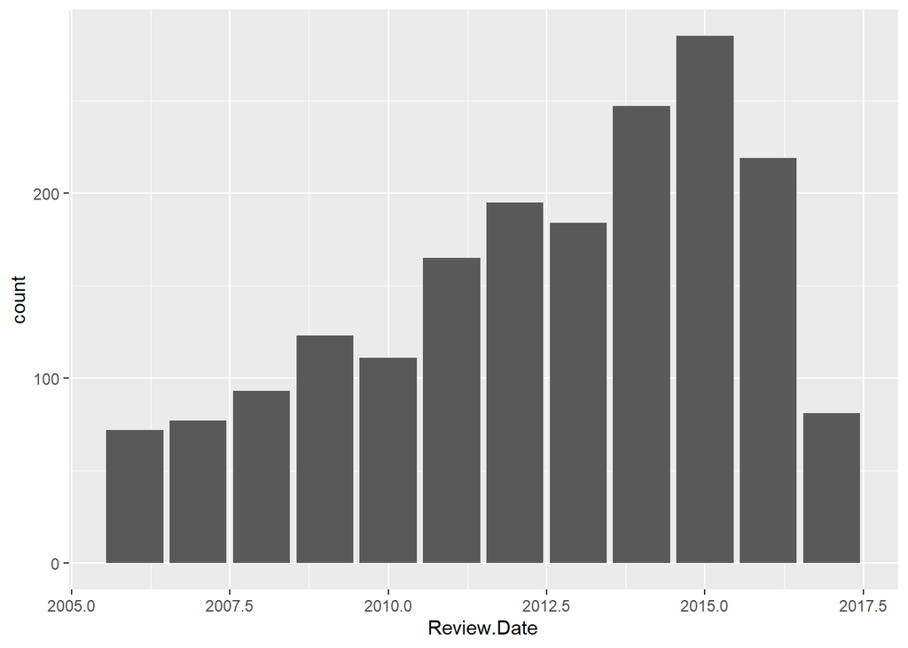

```r
library(ggplot2)
ggplot(data = choco, aes(x=Review.Date)) + geom_bar()
```

The number of ratings increases until 2015 and a sharp decline occurs.

**Question set 2**

1. How are ratings distributed? Draw a histogram of ratings and describe it. Don’t forget to mention outliers, if there are any.

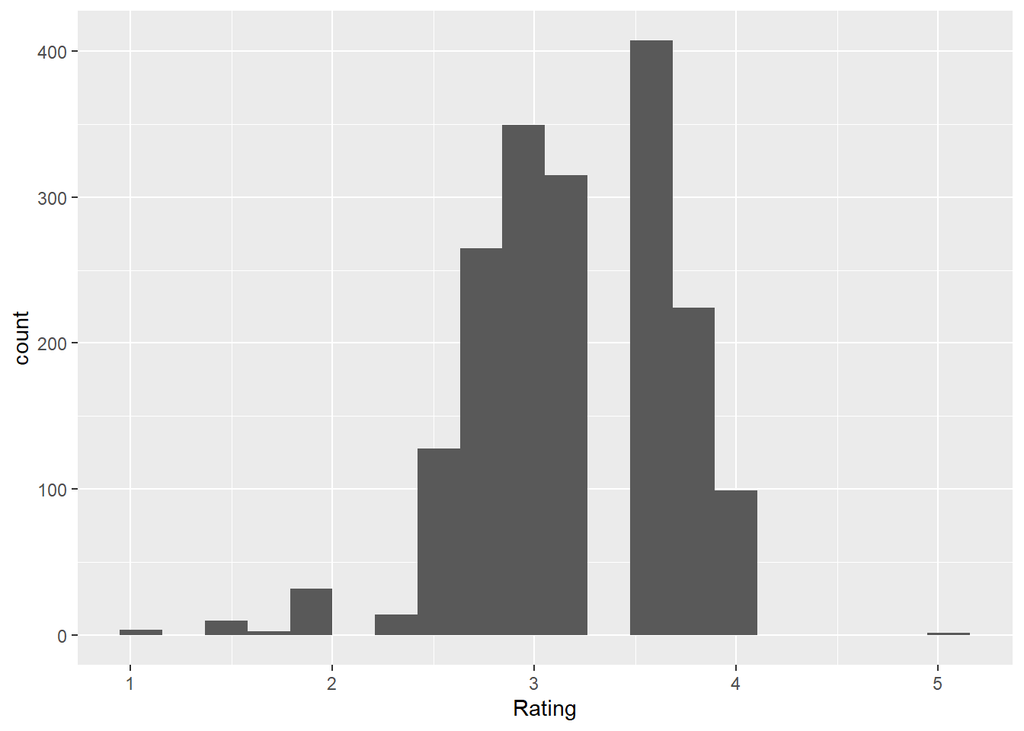

```r
ggplot(data = choco, aes(x =Rating)) + geom_histogram(bins = 20)
```

2. Do ratings depend on the cocoa percentage of a chocolate bar?

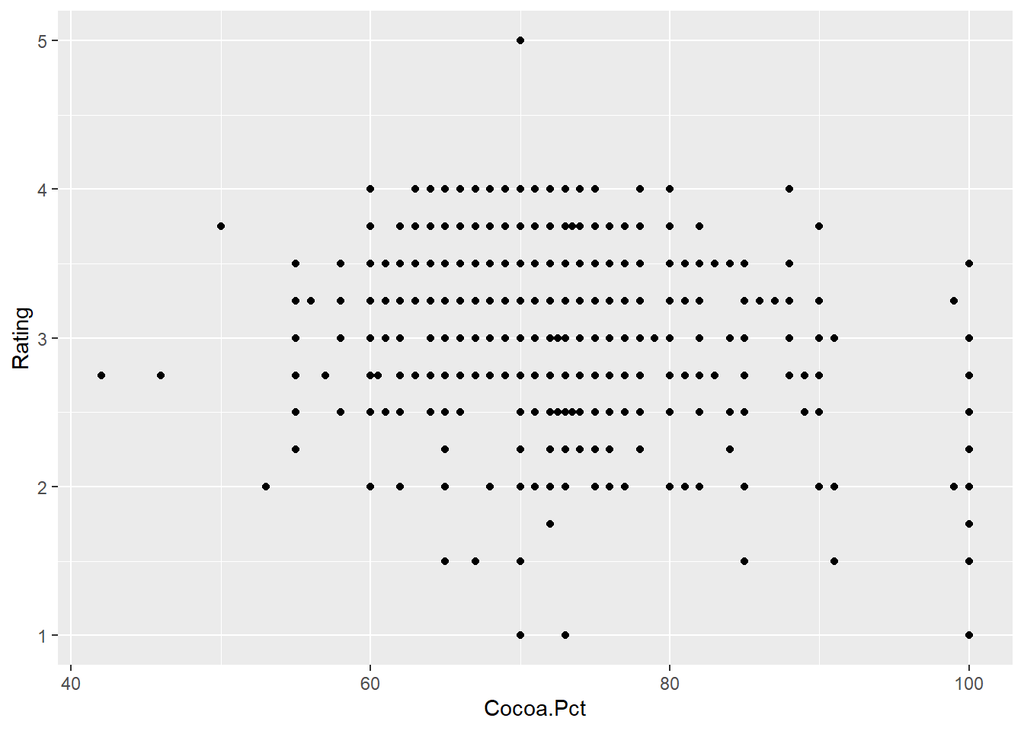

```r
ggplot(data = choco, aes(x = Cocoa.Pct, y = Rating)) + geom_point()
```

We can observe that the highest and lowest rating are from chocolate bar’s with 70% cocoa percentage, so we can’t really draw a conclusive statement from this graph alone.

```r
library(dplyr)
```

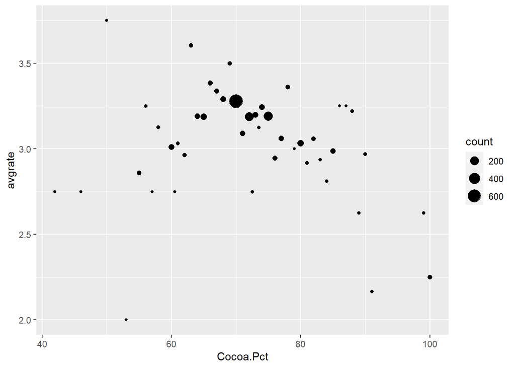

```r
pctdata = choco %>% group_by(Cocoa.Pct) %>% summarise(count = n(), avgrate = mean(Rating))

ggplot(data = pctdata, aes(x = Cocoa.Pct, y = avgrate)) + geom_point(aes(size = count))
```

By grouping cocoa percentage and plotting their average rating, we can note that 50% cocoa percentage yields the highest rating. However, there is likely prone to error as there is a relatively small sample size for chocolate bar with 50% cocoa percentage. Such, it is inconclusive if there are correlation between cocoa percentage and ratings.

3. How do ratings compare across different company locations? Focus on the three locations with the most ratings

```r
cmpcnt = choco %>% count(Company) %>% arrange(desc(n))
head(cmpcnt)
```

```
##    Company  n
## 1     Soma 47
## 2   Bonnat 27
## 3   Fresco 26
## 4   Pralus 25
## 5 A. Morin 23
## 6    Arete 22
```

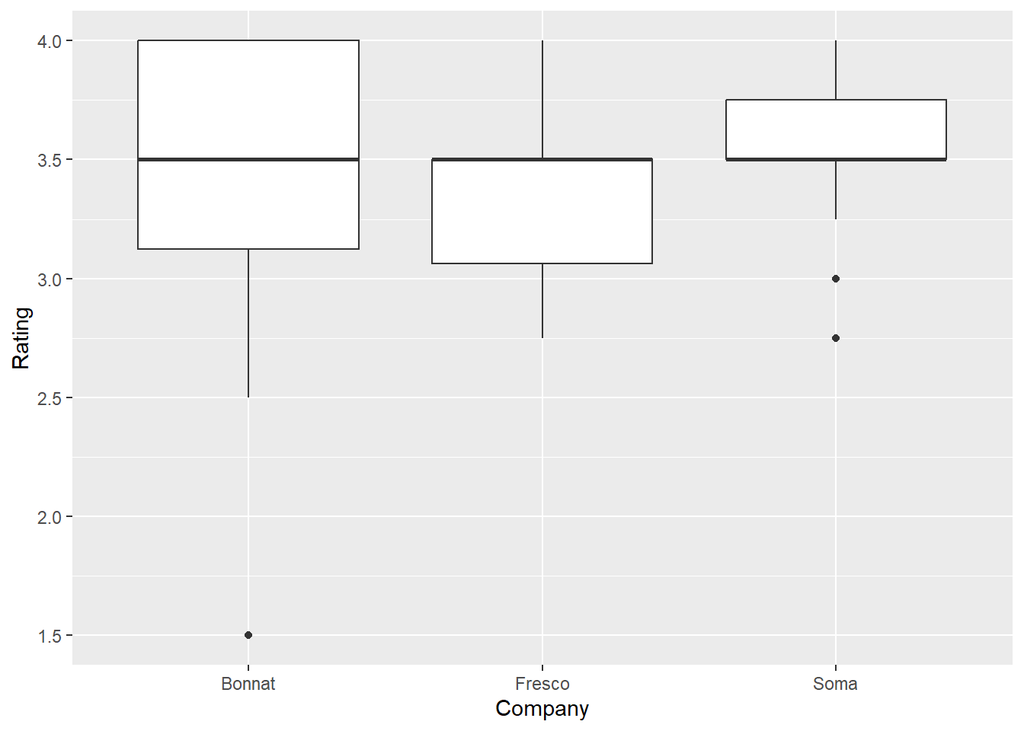

```r
cmpdata = choco %>% filter(Company %in% c('Soma', 'Bonnat', 'Fresco'))
ggplot(data = cmpdata, aes(x = Company, y = Rating)) + geom_boxplot()
```

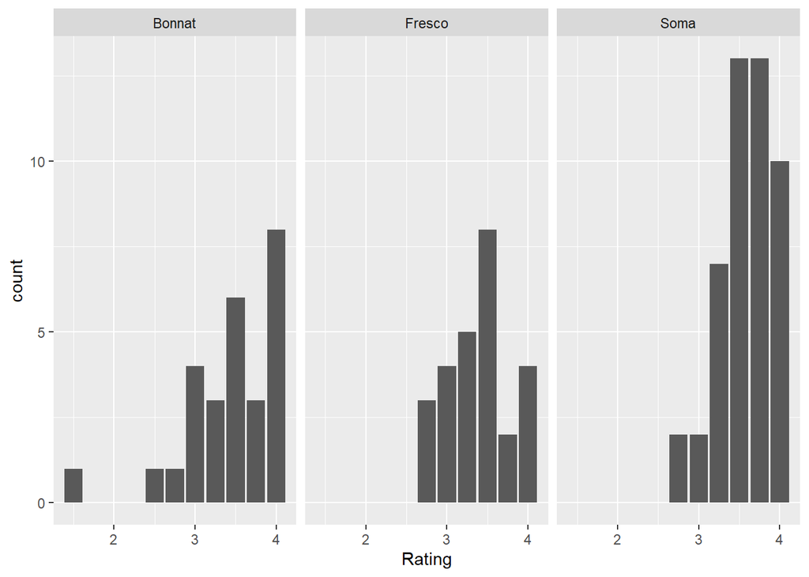

```r
ggplot(data = cmpdata, aes(x = Rating)) + geom_bar() + facet_wrap(~Company)
```

Bonnat has percentile of its rating’s around 4 which is by far the highest comparatively amongst the three company. Whereas, Soma has the highest mean rating for their chocolate with a dense collection around 3.5 and above. Fresco similarly has most of its rating averaging around 3.5, though it has lesser bars proportionately above that.

**Own question**

1. (Roy) Which location produces the bean with the highest average rating with at least 10 rating?

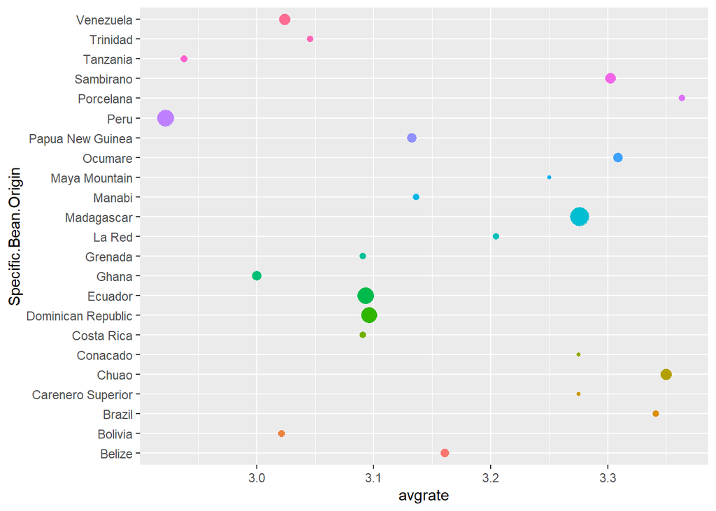

```r
beandata = choco %>% group_by(Specific.Bean.Origin) %>% summarise(count = n(), avgrate = mean(Rating)) %>% filter(count >= 10)

ggplot(data = beandata, aes(x = Specific.Bean.Origin, y = avgrate)) + geom_point(aes(size = count, color = Specific.Bean.Origin), show.legend = FALSE) + coord_flip()
```

From the plot, we can see that Porcelana produces the highest average rated beans compared to other region.

2. (Xuan Wen) Which year produces the best chocolate?

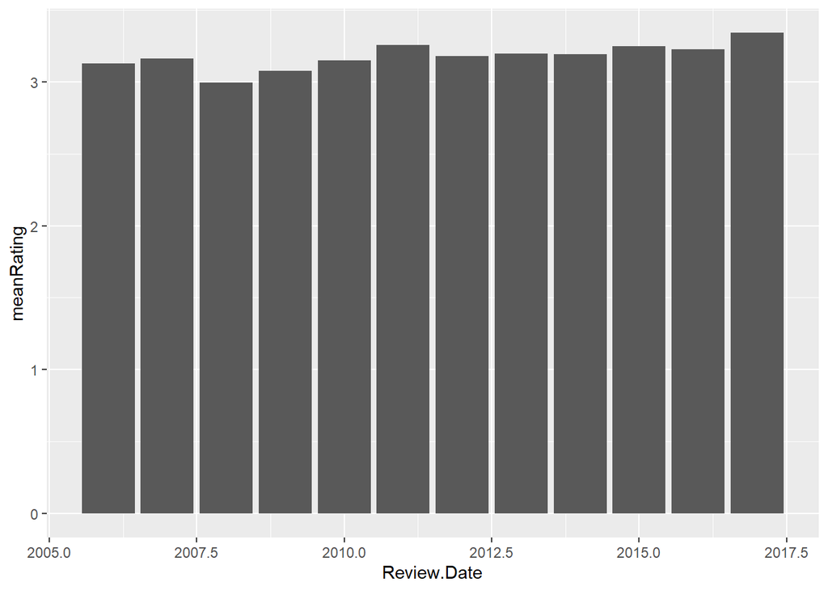

```r
yearRating = choco %>% group_by(Review.Date) %>% summarise(meanRating = mean(Rating))
ggplot(data = yearRating, aes(x=Review.Date, y=meanRating)) + geom_bar(stat="identity")
```

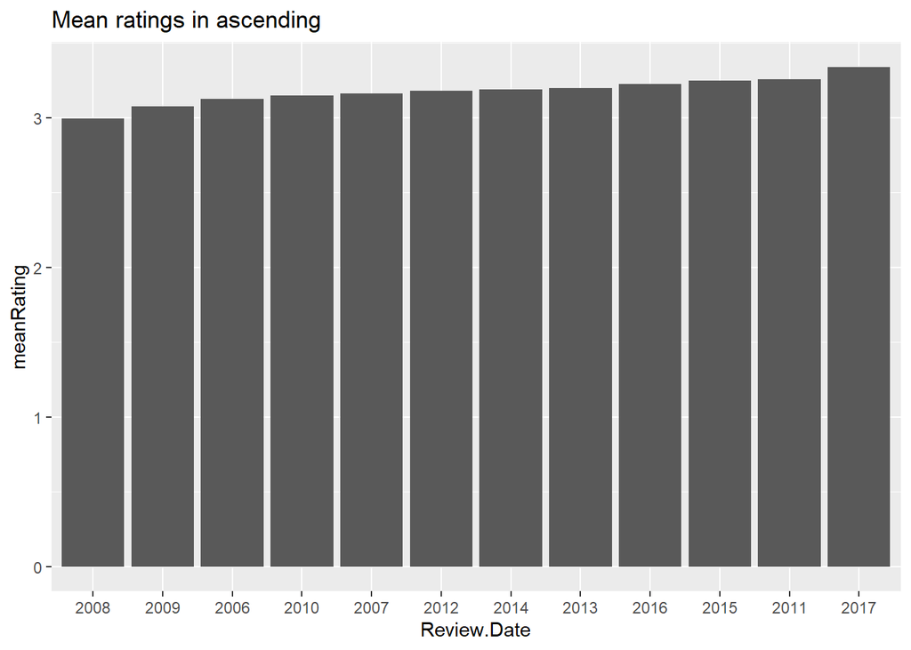

```r
library(forcats)
yearRating_sort = yearRating%>% arrange(meanRating)
yearRating_sort$Review.Date = as.character(yearRating_sort$Review.Date)
ggplot(data = yearRating_sort, aes(x=fct_reorder(Review.Date,meanRating), y=meanRating)) + geom_bar(stat="identity") + xlab("Review.Date") + ggtitle("Mean ratings in ascending")
```

From the chart, we can say that year 2017 produces the best chocolate since it has the highest average rating.